# Economie des ressources renouvelables

Simon Jean

simon.jean@agroparistech.fr

AgroParisTech - CIRED - PSAE

# Introduction

Ce cours est repris du cours de [Vincent Martinet](https://sites.google.com/site/martinetvincent/home/teaching/eddee), directeur de recherche INRAE à Paris Saclay Applied Economics, qui l’enseigne habituellement. Il est cette année en visite académique à [l’Environmental Markets Lab (emLab)](https://emlab.ucsb.edu/). Je le remerice chaleureusement!

# I. Le modèle de Gordon Schaeffer

## Biologie du modèle

Schaeffer (1954) développe les notations suivantes :

**La fonction logistique**

Développée par Pierre François Verhulst (1838) dans *Notice sur la loi que la population suit dans son accroissement.*, en réaction aux théories démographiques développées par Malthus, supposant une croissance exponentielle des populations. Verhulst introduit une *rétroaction* du niveau de population : lorsque la population devient trop proche de ses limites écologiques, elle tend à réduire. Cette contribution est redécouverte au cours des années 1920-1930 pour modéliser les populations animales et végétales.

$$\frac{dB_t}{dt} = rB_t \left(1 - \frac{B_t}{B_{sup}}\right)$$

Où $r$ est le taux de croissance intrinsèque (quand la population est proche de 0) et mesure la rapidité de convergence vers la capacité de charge

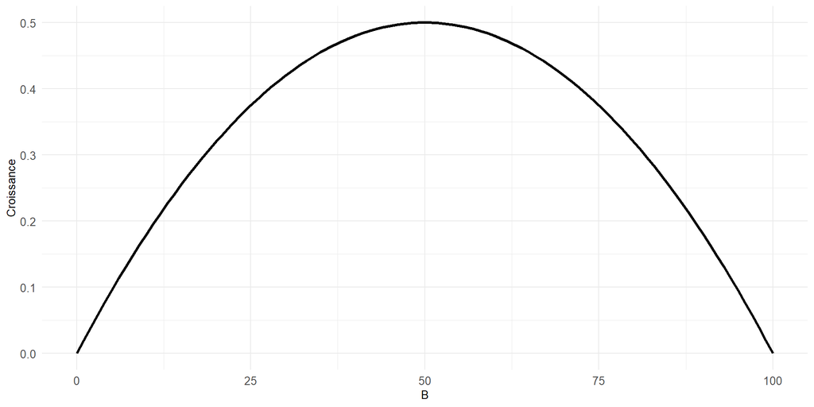